# Love… Never Heard of It

Larry Brodetskiy

As “Love… Never Heard of It” is a biographical drama, it is best to first subset the data that we are given in order to focus specifically on drama movies. This will give us a more accurate predicition of how the movie will perform once it is released.

```r
dramamovies <- subset(hollywood, genre=="Drama")
```

One variable that should be considered is Rotten Tomatoes rating, as ratings often affect the amount of viewers that go to see a given movie.

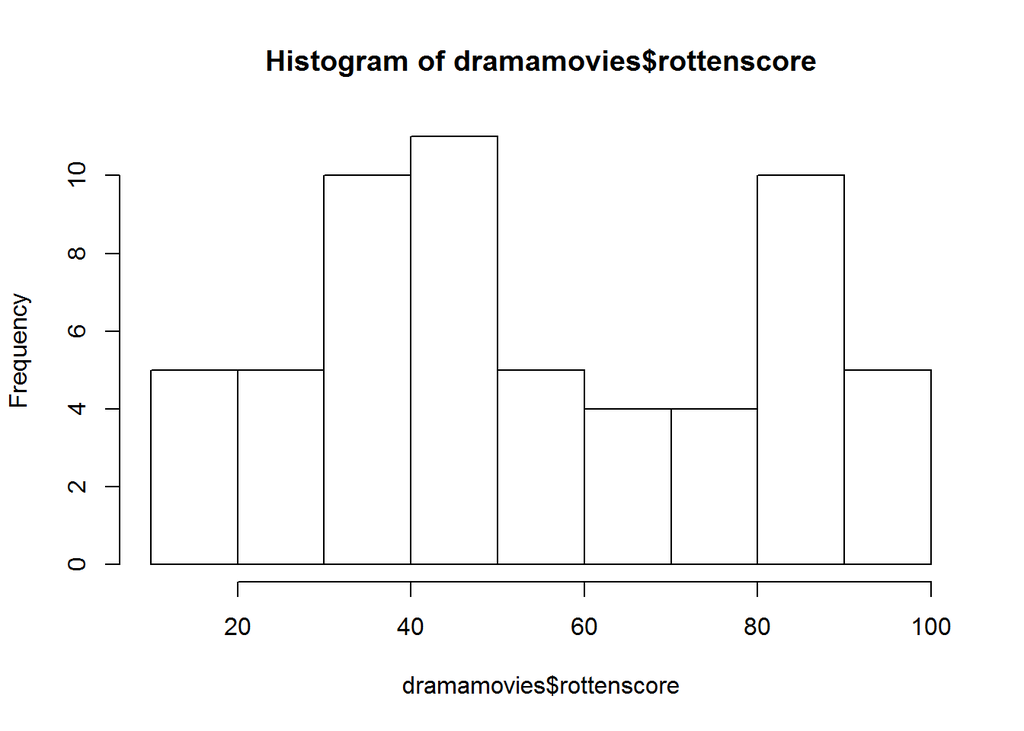

```r
hist(dramamovies$rottenscore)
```

```r
mean(dramamovies$rottenscore)
```

```
## [1] 55.23729
```

```r
median(dramamovies$rottenscore)
```

```
## [1] 50
```

Looking at the average and median Rotten Tomatoes ratings given to drama movies, “Love.. Never Heard of It” performed slightly better than average, receiving a score of 59 compared to the average score of about 55 and the median score of 50.

A potentially good indicator of how well a movie performed is its gross income for all viewers worldwide. It is a good idea to examine if a relationship exists between a drama movie’s Rotten Tomatoes rating and its worldwide gross.

```r
plot(dramamovies$rottenscore,dramamovies$WWgross,main="Drama Movie Rotten Score vs Drama Movie Worldwide Gross")
lm(dramamovies$WWgross~dramamovies$rottenscore)
```

```
##
## Call:
## lm(formula = dramamovies$WWgross ~ dramamovies$rottenscore)
##
## Coefficients:
##             (Intercept)  dramamovies$rottenscore
##               109.27604                 -0.05087
```

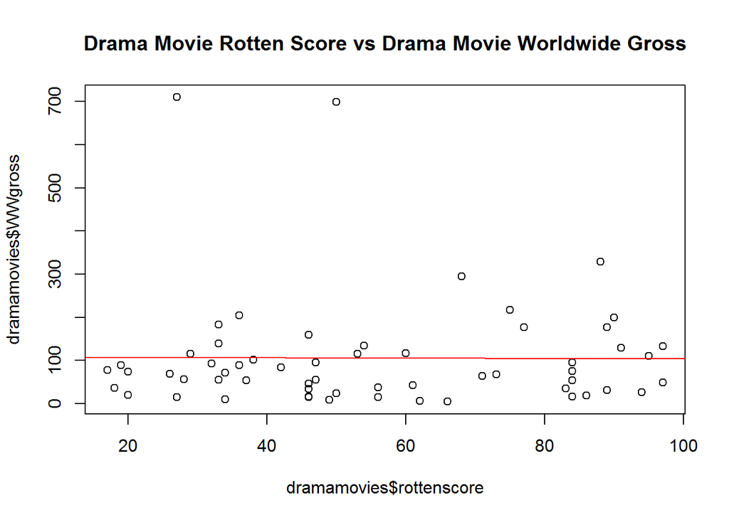

```r
abline(109.27604,-0.05087, col="red")
```

```r
cor(dramamovies$rottenscore, dramamovies$WWgross)
```

```
## [1] -0.009405559
```

There appears to be no correlation between the two variables. Looking at the non-subseted data could give us a clear indication as to whether these two variables are related.

```r
plot(rottenscore,WWgross,main="Rotten Score vs Worldwide Gross")
lm(WWgross~rottenscore)
```

```
##
## Call:
## lm(formula = WWgross ~ rottenscore)
##
## Coefficients:
## (Intercept)  rottenscore
##      88.181        1.746
```

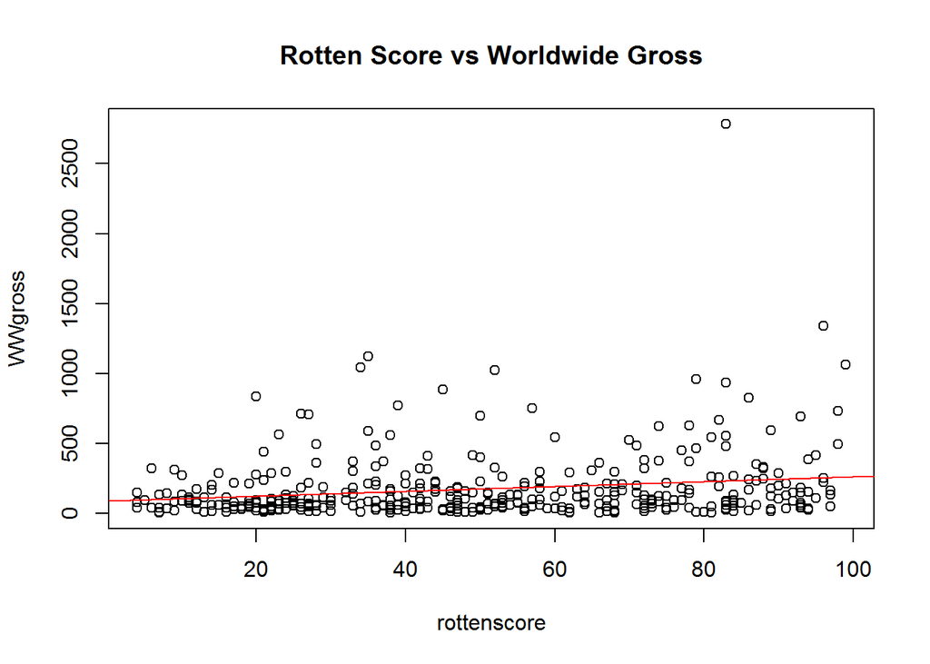

```r
abline(88.181, 1.746, col="red")
```

```r
cor(rottenscore, WWgross)
```

```
## [1] 0.190342
```

While there is some correlation between the variables in the non-subseted data, the correlation is very weak, therefore examining this relationship will not help to determine how the movie will perform.

Another potentially good indicator of how well a movie performed is its percent profit. It is a good idea to examine if a relationship exists between a drama movie’s Rotten Tomatoes rating and its percent profit.

```r
plot(dramamovies$rottenscore, dramamovies$percentprofit,main="Drama Movie Rotten Score vs Drama Movie Percent Profit")
lm(dramamovies$percentprofit~dramamovies$rottenscore)
```

```
##
## Call:
## lm(formula = dramamovies$percentprofit ~ dramamovies$rottenscore)
##
## Coefficients:
##             (Intercept)  dramamovies$rottenscore
##                  73.929                    6.336
```

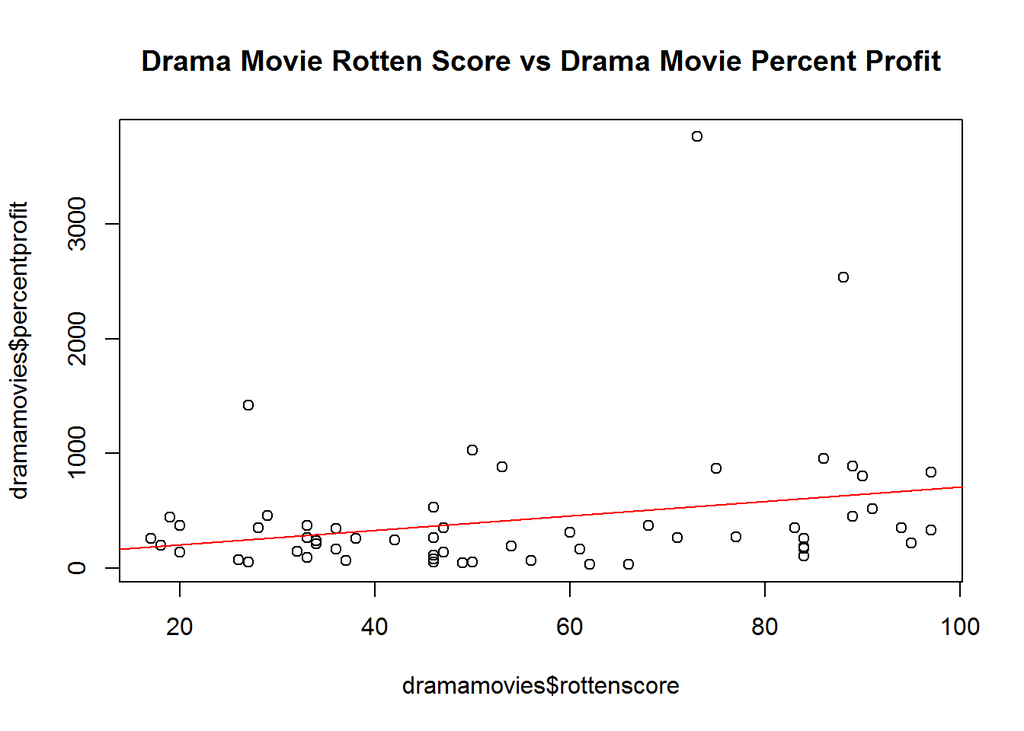

```r
abline(73.929,6.336, col="red")
```

```r
cor(dramamovies$rottenscore, dramamovies$percentprofit)
```

```
## [1] 0.2583036
```

There appears to be a weak correlation between the two variables. Looking at the non-subseted data could give us a clear indication as to whether these two variables are related.

```r
plot(rottenscore, percentprofit,main="Rotten Score vs Percent Profit")
lm(percentprofit~rottenscore)
```

```
##
## Call:
## lm(formula = percentprofit ~ rottenscore)
##
## Coefficients:
## (Intercept)  rottenscore
##     -4043.6        154.3
```

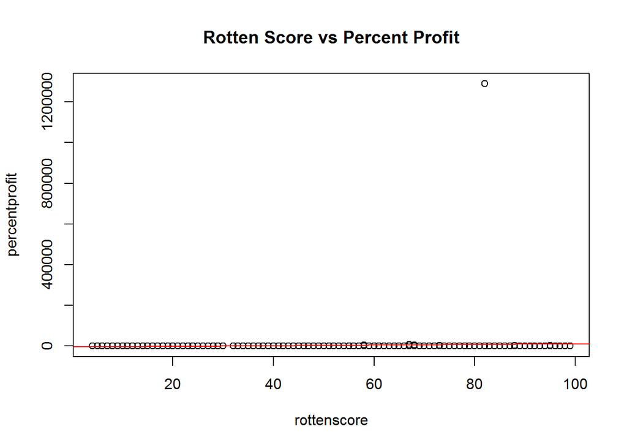

```r
abline(-4043.6, 154.3, col="red")
```

```r
cor(rottenscore, percentprofit)
```

```
## [1] 0.06280724
```

A weak correlation exists between the variables, therefore it can be determined that Rotten Tomatoes rating is not useful in determining how a movie will perform. Perhaps examing preview audience rating will yield different results.

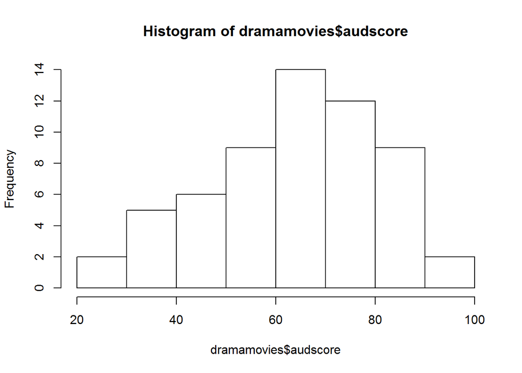

```r
hist(dramamovies$audscore)
```

```r
mean(dramamovies$audscore)
```

```
## [1] 63.83051
```

```r
median(dramamovies$audscore)
```

```
## [1] 66
```

Looking at the average and median preview audience ratings given to drama movies, “Love.. Never Heard of It” performed slightly better than average, receiving a score of 76 compared to the average score of about 64 and the median score of 66.

It is a good idea to examine if a relationship exists between a drama movie’s preview audience rating and its worldwide gross.

```r
plot(dramamovies$audscore, dramamovies$WWgross,main="Drama Movie Audience Rating vs Drama Movie Worldwide Gross")
lm(dramamovies$WWgross~dramamovies$audscore)
```

```
##
## Call:
## lm(formula = dramamovies$WWgross ~ dramamovies$audscore)
##
## Coefficients:
##          (Intercept)  dramamovies$audscore
##              -35.775                 2.228
```

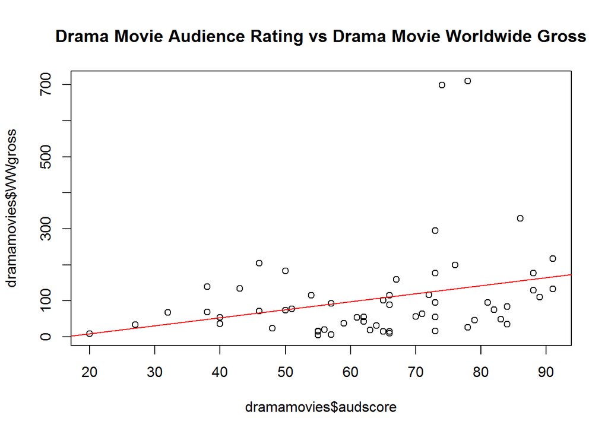

```r
abline(-35.775, 2.228, col="red")
```

```r
cor(dramamovies$audscore, dramamovies$WWgross)
```

```
## [1] 0.2809133
```

There appears to be a weak correlation between the two variables. Looking at the non-subseted data could give us a clear indication as to whether these two variables are related.

```r
plot(audscore, WWgross,main="Audience Rating vs Worldwide Gross")
lm(WWgross~audscore)
```

```
##
## Call:
## lm(formula = WWgross ~ audscore)
##
## Coefficients:
## (Intercept)     audscore
##    -180.735        6.014
```

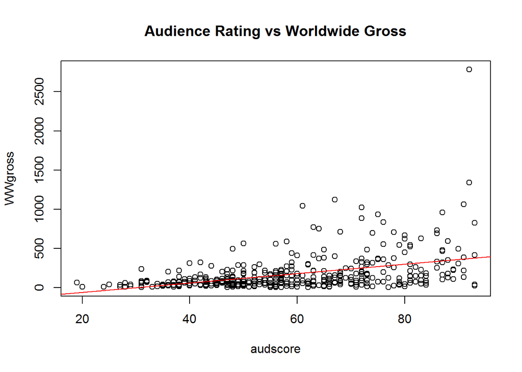

```r
abline(-180.735, 6.014, col="red")
```

```r
cor(audscore, WWgross)
```

```
## [1] 0.4082113
```

While there is some correlation between the variables in the non-subseted data, the correlation is weak, therefore examining this relationship will not help to determine how the movie will perform.

It is a good idea to examine if a relationship exists between a drama movie’s preview audience rating and its percent profit.

```r
plot(dramamovies$audscore, dramamovies$percentprofit,main="Drama Movie Audience Rating vs Drama Movie Percent Profit")
lm(dramamovies$percentprofit~dramamovies$audscore)
```

```
##
## Call:
## lm(formula = dramamovies$percentprofit ~ dramamovies$audscore)
##
## Coefficients:
##          (Intercept)  dramamovies$audscore
##              181.649                 3.796
```

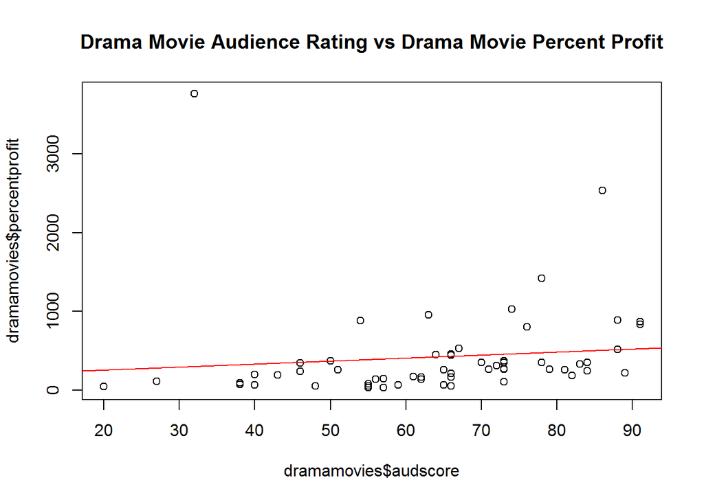

```r
abline(181.649, 3.796, col="red")
```

```r
cor(dramamovies$audscore, dramamovies$percentprofit)
```

```
## [1] 0.1054904
```

There appears to be a weak correlation between the two variables. Looking at the non-subseted data could give us a clear indication as to whether these two variables are related.

```r
plot(audscore, percentprofit,main="Audience Rating vs Percent Profit")
lm(percentprofit~audscore)
```

```
##
## Call:
## lm(formula = percentprofit ~ audscore)
##
## Coefficients:
## (Intercept)     audscore
##     5605.81       -32.72
```

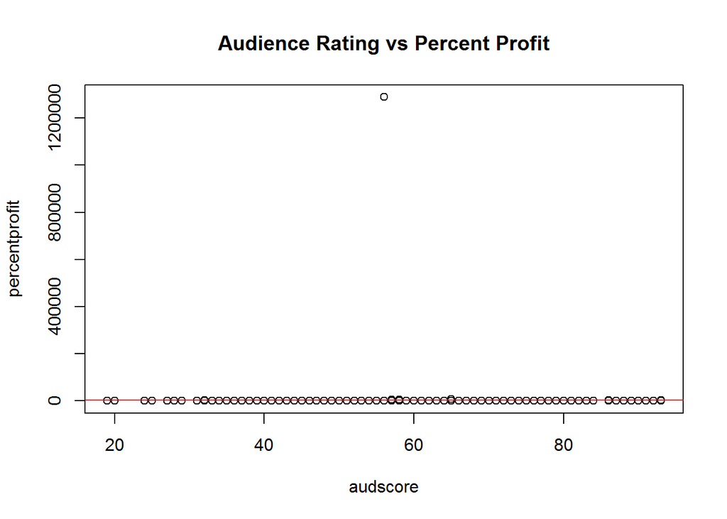

```r
abline(5605.81, -32.72, col="red")
```

```r
cor(audscore, percentprofit)
```

```
## [1] -0.008293286
```

A very weak correlation exists between the variables, therefore it can be determined that preview audience rating is not useful in determining how a movie will perform. Perhaps examing number of screens for opening weekend will yield different results.

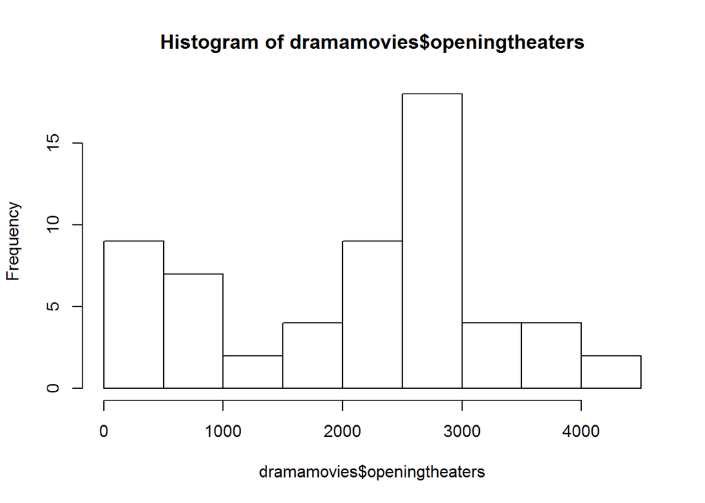

```r
hist(dramamovies$openingtheaters)
```

```r
mean(dramamovies$openingtheaters)
```

```
## [1] 2048.508
```

```r
median(dramamovies$openingtheaters)
```

```
## [1] 2376
```

Looking at the average and median number of screens for opening weekend specifically for drama movies, “Love.. Never Heard of It” opened at significantly more theaters than average, opening at 3145 theaters compared to the average number of theaters being about 2049 and the median number of theaters being 2376.

It is a good idea to examine if a relationship exists between a drama movie’s number of screens for opening weekend and its worldwide gross.

```r
plot(dramamovies$openingtheaters, dramamovies$WWgross,main="Drama Movie Opening Theaters vs Drama Movie Worldwide Gross")
lm(dramamovies$WWgross~ dramamovies$openingtheaters)
```

```
##
## Call:
## lm(formula = dramamovies$WWgross ~ dramamovies$openingtheaters)
##
## Coefficients:
##                 (Intercept)  dramamovies$openingtheaters
##                    -2.46210                      0.05317
```

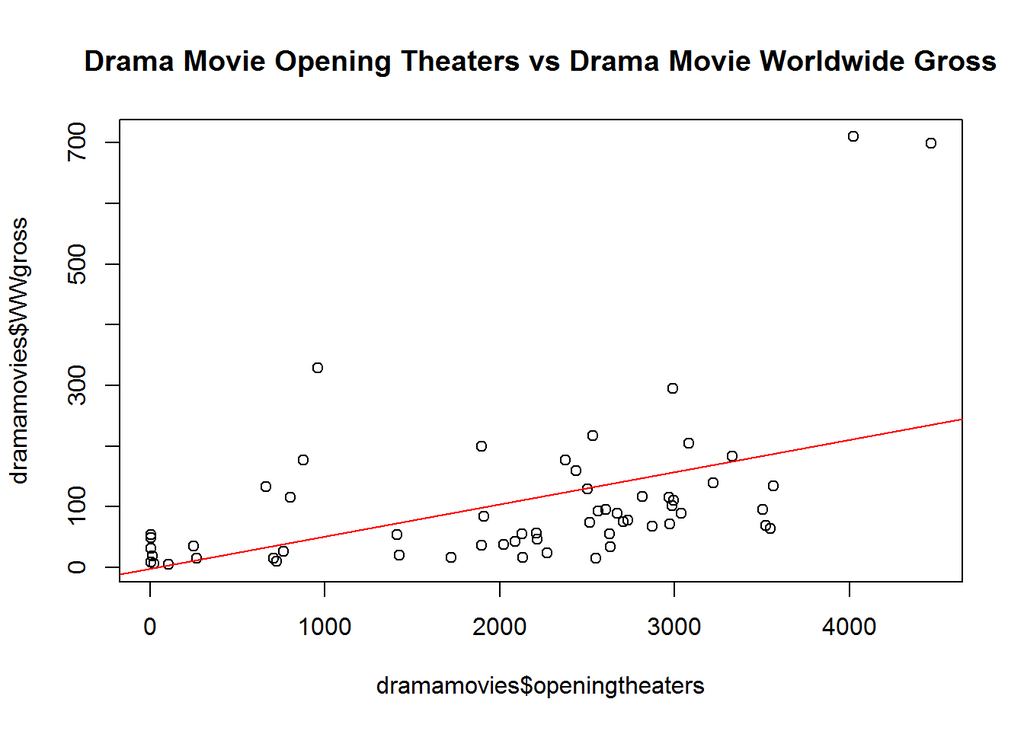

```r
abline(-2.46210, 0.05317, col="red" )
```

```r
cor(dramamovies$openingtheaters, dramamovies$WWgross)
```

```
## [1] 0.4722323
```

There appears to be a weak correlation between the two variables. Looking at the non-subseted data could give us a clear indication as to whether these two variables are related.

```r
plot(openingtheaters, WWgross,main="Opening Theaters vs Worldwide Gross")
lm(openingtheaters~ WWgross)
```

```
##
## Call:
## lm(formula = openingtheaters ~ WWgross)
##
## Coefficients:
## (Intercept)      WWgross
##    2391.461        1.875
```

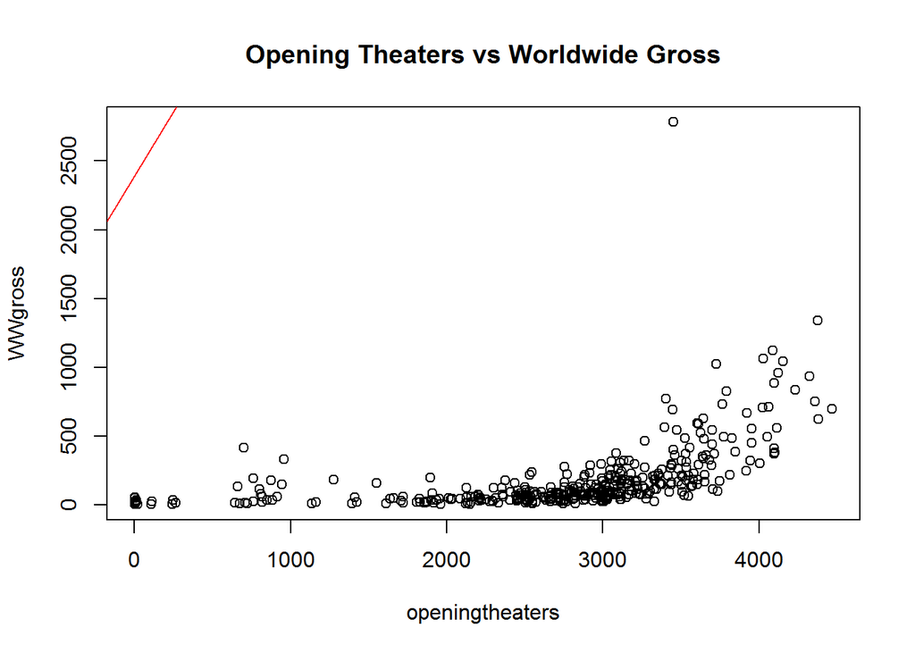

```r
abline(2391.461, 1.875, col="red" )
```

```r
cor(openingtheaters, WWgross)
```

```
## [1] 0.4831227
```

While there is some correlation between the variables in the non-subseted data, the correlation is weak, therefore examining this relationship will not help to determine how the movie will perform.

It is a good idea to examine if a relationship exists between a drama movie’s number of screens for opening weekend and its percent profit.

```r
plot(dramamovies$openingtheaters, dramamovies$percentprofit,main="Drama Movie Opening Theaters vs Drama Movie Percent Profit")
lm(dramamovies$percentprofit~dramamovies$openingtheaters)
```

```
##
## Call:
## lm(formula = dramamovies$percentprofit ~ dramamovies$openingtheaters)
##
## Coefficients:
##                 (Intercept)  dramamovies$openingtheaters
##                   358.40329                      0.03199
```

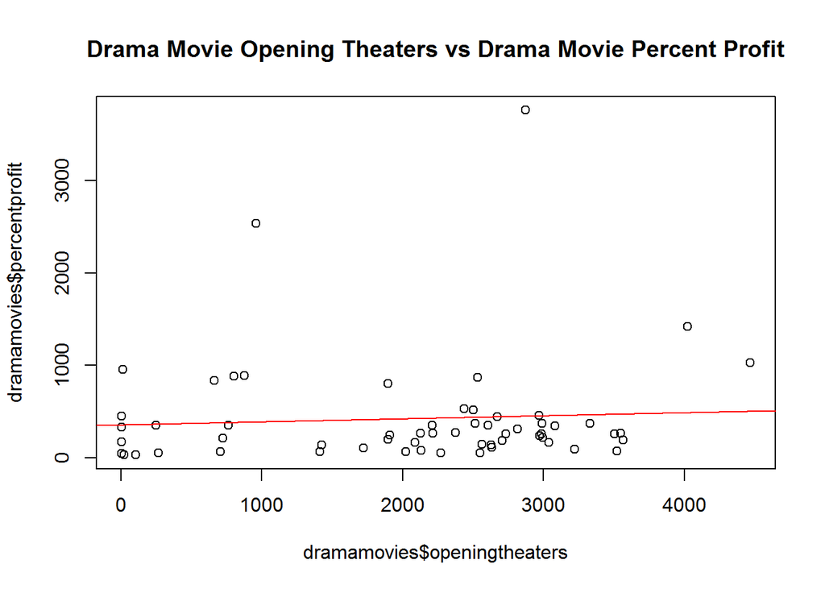

```r
abline(358.40329, 0.03199, col="red" )
```

```r
cor(dramamovies$openingtheaters, dramamovies$percentprofit)
```

```
## [1] 0.0626278
```

There appears to be a weak correlation between the two variables. Looking at the non-subseted data could give us a clear indication as to whether these two variables are related.

```r
plot(openingtheaters, percentprofit,main="Opening Theaters vs Percent Profit")
lm(percentprofit~openingtheaters)
```

```
##
## Call:
## lm(formula = percentprofit ~ openingtheaters)
##
## Coefficients:
##     (Intercept)  openingtheaters
##       23343.998           -7.233
```

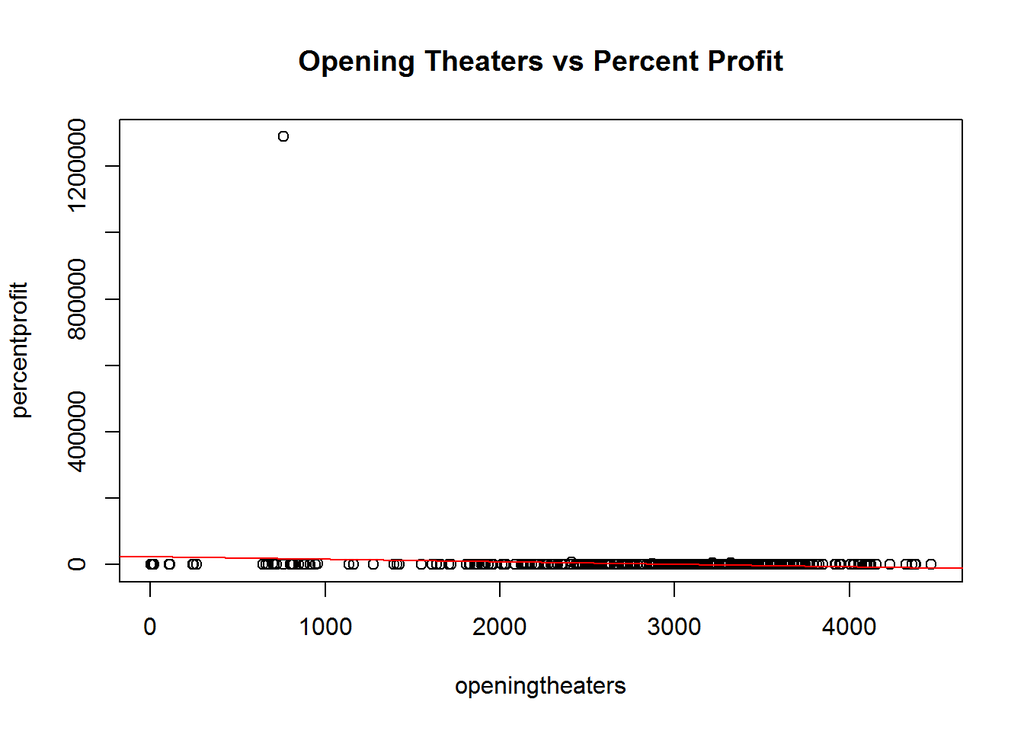

```r
abline(23343.998, -7.233, col="red")
```

```r
cor(openingtheaters, percentprofit)
```

```
## [1] -0.1048181
```

A very weak correlation exists between the variables, therefore it can be determined that number of screens for opening weekend is not useful in determining how a movie will perform. Perhaps examing budget will yield different results.

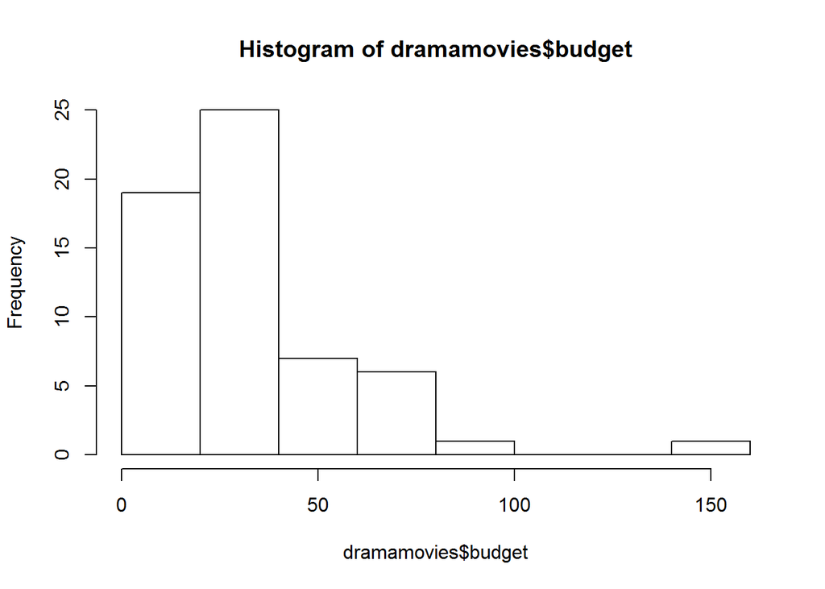

```r
hist(dramamovies$budget)
```

```r
mean(dramamovies$budget)
```

```
## [1] 34.33559
```

```r
median(dramamovies$budget)
```

```
## [1] 26
```

Looking at the average and median budgets specifically for drama movies, “Love.. Never Heard of It” had a significantly larger budget of $64 million compared to the average budget being about $34 million and the median budget being $26 million.

It is a good idea to examine if a relationship exists between a drama movie’s budget and its worldwide gross.

```r
plot(dramamovies$budget, dramamovies$WWgross,main="Drama Movie Budget vs Drama Movie Worldwide Gross")
lm(dramamovies$WWgross~ dramamovies$budget)
```

```
##
## Call:
## lm(formula = dramamovies$WWgross ~ dramamovies$budget)
##
## Coefficients:
##        (Intercept)  dramamovies$budget
##             52.670               1.567
```

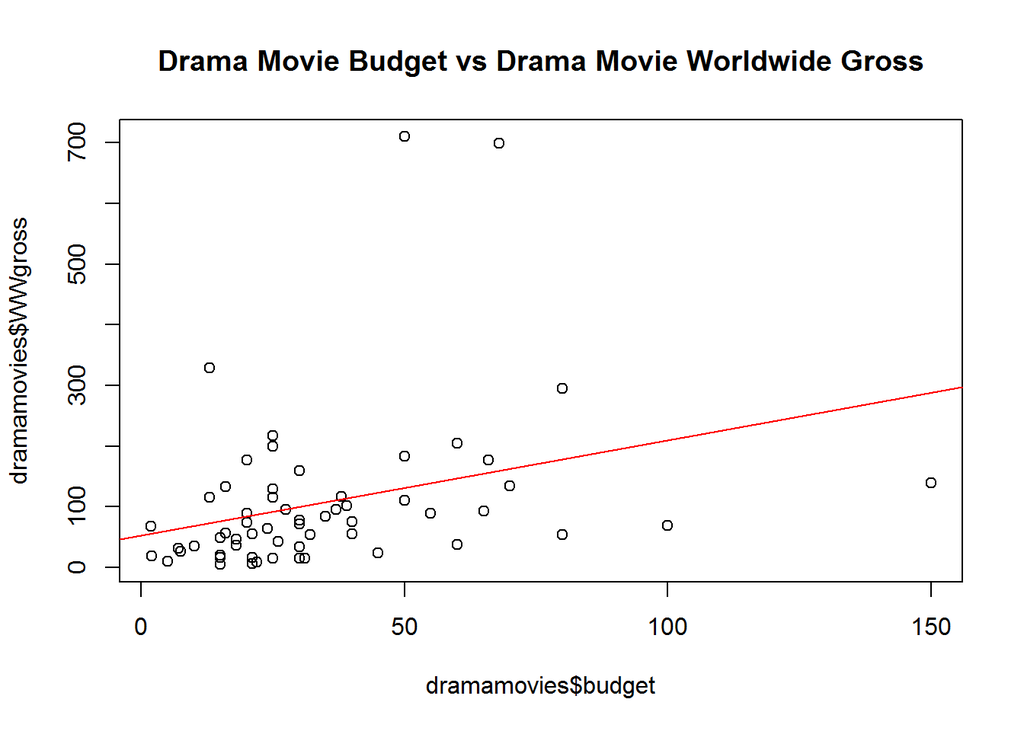

```r
abline(52.670, 1.567, col="red")
```

```r
cor(dramamovies$budget, dramamovies$WWgross)
```

```
## [1] 0.3086355
```

There appears to be a weak correlation between the two variables. Looking at the non-subseted data could give us a clear indication as to whether these two variables are related.

```r
plot(budget, WWgross,main="Budget vs Worldwide Gross")
lm(WWgross~budget)
```

```
##
## Call:
## lm(formula = WWgross ~ budget)
##
## Coefficients:
## (Intercept)       budget
##     -13.332        3.292
```

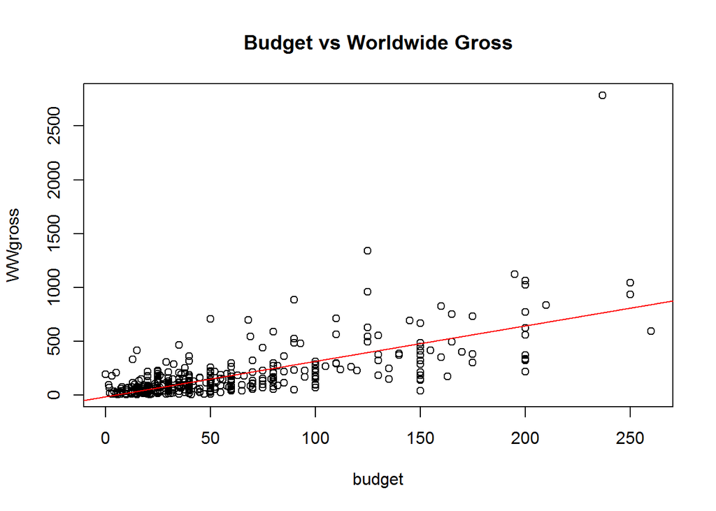

```r
abline(-13.332, 3.292, col="red")
```

```r
cor(budget, WWgross)
```

```
## [1] 0.6957578
```

There is a strong positive correlation between the variables in the non-subseted data, therefore it can be said that movies with big budgets typically generate a lot of money on a global scale. This relationship can be used to determine the kind of movie that Paramount Pictures should make next by examining which movie genres typically have bigger budgets.

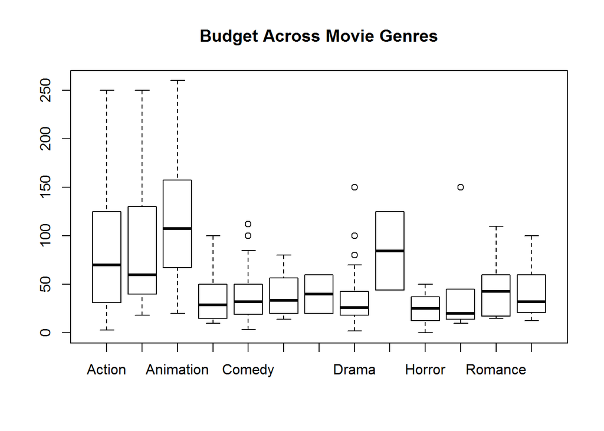

```r
boxplot(budget~genre,main="Budget Across Movie Genres")
```

Examining this boxplot, it becomes clear that animation movies typically have the largest budget when compared to other movie genres. By this logic, Paramount should focus on making animation movies. In order to understand how much money the studio should invest into these movies and how many theaters these movies should be released in, the data must first be subseted to specifically animation movies.

```r
animationmovies <- subset(hollywood, genre=="Animation")
```

A histogram of the budgets of animation movies will reveal an accurate estimate of how much money Paramount should invest.

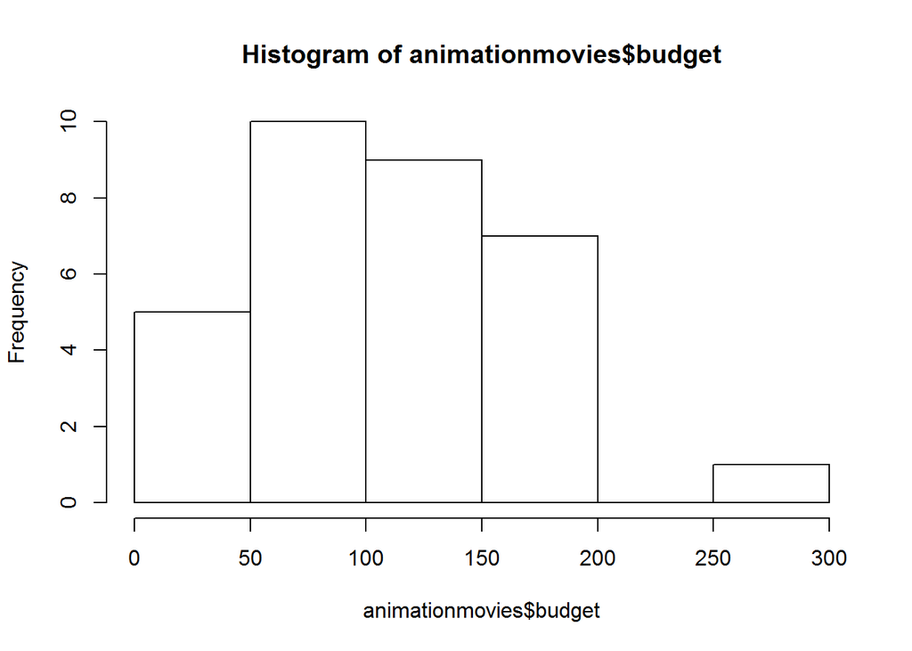

```r
hist(animationmovies$budget)
```

```r
mean(animationmovies$budget)
```

```
## [1] 114.1562
```

```r
median(animationmovies$budget)
```

```
## [1] 107.5
```

The average budget for an animation movie is about $114 million, therefore Paramount should invest roughly $115-120 million on an animation movie.

A histogram of the number of screens for opening weekend for animation movies will reveal an accurate estimate of how many theaters Paramount should release its next movie in.

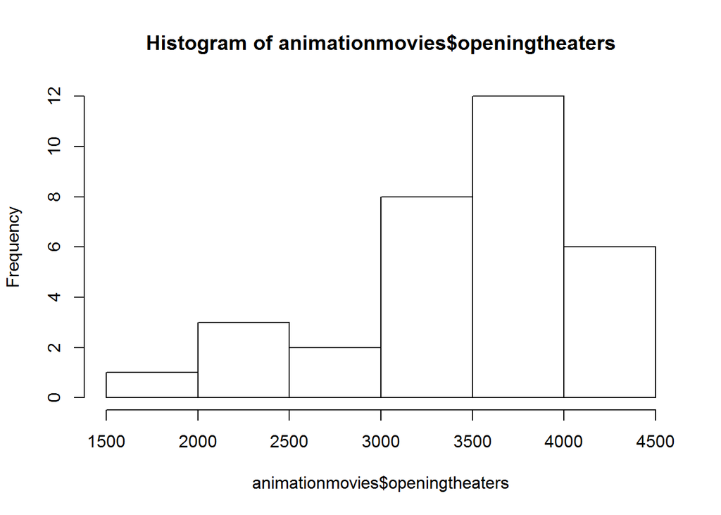

```r
hist(animationmovies$openingtheaters)
```

```r
mean(animationmovies$openingtheaters)
```

```
## [1] 3431.844
```

```r
median(animationmovies$openingtheaters)
```

```
## [1] 3591
```

The average number of screens for opening weekend for an animation movie is about 3432, therefore Paramount should open this movie in 3450-3500 theaters.

In conclusion, Paramount should invest $115-120 million in an animation movie that will open in 3450-3500 theaters. Based on the data collected, it is demonstrated that the budget of a movie is the best predictor for how well that movie will do. Speaking on “Love… Never Heard of It”, this movie is overall better compared to the average drama. Reiterating data collected from before, the movie received a better Rotten Tomatoes rating and a better preview audience rating compared to the average drama (59 compared to 55 for Rotten Tomatoes and 76 compared to 64 for preview audiences.) Furthermore, the movie released in many more theaters than the average drama and was given a larger budget than the average drama (3145 theaters compared to 2049 theaters and $64 million compared to $34 million.) Despite these figures, the weak correlations in the data above suggests that it is difficult to determine if “Love… Never Heard of It” will perform well once it is released. However, Paramount can take comfort in knowing that the movie is better compared to the average drama across various statistical categories as described above. There are certain biases that arise from the data set. Firstly, there is not an equal amount of movies per genre represented in the data set. For example, there are 59 dramas in the data set compared to 103 action movies. Secondly, there are noticeable outliers that affect the reliability of the data set. For example, the percent profit for Paranormal Activity is over a million percent due to the fact that it is an independent movie which did not cost a lot to create. There are several ways to improve the data gathering methods. First of all, the data set is too broad. Limiting the data set to movies produced by a certain studio or within a two-year span rather than a three-year span will lead to more accurate predictions of how well a movie will do once it is released. Secondly, taking into account audience reactions after the movie is released is a necessary element that is missing here, as people often choose whether or not to see a movie based on the opinion of their friend or colleague that has already seen it. Because of how general this data set is, the conclusions drawn from it are not solid, as supported by the data above. Most of the correlations that were found were weak, and this can be attributed to the unreliability of the data set. Therefore, it becomes clear that the more specificed a data set is, the more solid analysis and interpretation can be made from it.